# fit

## How to build a regression model

- What variables to include, what to leave out, etc.
- 3 standard approaches: 1. Use theory 2. Let the data decide 3. Compare models

## Prediction

- Our inferences are about populations
- Want to generalize to other samples
- three standard goals of regression:
  1. Explain
  2. Predict
  3. Estimate

## Prediction

```r
pred.1 <- predict(model.1)
```

## When do we have a good model?

- Look at fit, but fit is relative to our question at hand
- Does it include all relevent variables (remember our assumption)?
- Balance between parsimony and completeness
- “Building” models up or “pruning” models down

## Overfitting

- We don’t always want the best model fit
- This is because the model will be tuned to our particular random sample, but not other random samples
- We are “fitting the noise”
- Not only does the extra terms not help, they actually hurt!
- This would lead to poorer prediction of new samples.
- Our goal is to identify the true population model, not just increase fit

## Overfitting

- Even if we have a set number of predictors we are going to use we tend ot overfit

\[ \hat{Y} = b_{0} + b_{1}X + b_{2}Z + b_{3}XZ \]

\[ \hat{Y} = .6 + .9X + .4Z + -.24XZ \] - because we use the specifics (which include sampling error) of that sample to estimate our coefficients

## Relationship to p-hacking

- Making your model work ie finding the set of covariates that make a p-value fall under .05 will lead to over fitting.
- This means that prediction will be even worse than the typical under powered experiment

## Cross validation

- Compare different models in their prediction in and out of sample (a test sample)
- Identify the model with the lowest test set error (MSE)
- Not always possible to find a large enough test sample

## k-fold validation

- Samples are randomly partitioned into sets (called folds) of roughly equal size
- model is “trained” on k-1 folds, and then validated with the remaining fold
- k is usually 5-10
- E.g., k = 10, 90% of data is used to train, 10% to predict and validate.
- Average MSE across all of the validation folds, choose model with lowest average MSE

## leave one out (LOO) validation

- like k-fold but but k = sample size, N.
- Run model with kth datapoint omitted.
- Observe the average MSE or residual standard error (sigma)
- compare the average MSE among competing models

```r
library(caret)
# we will use the iris dataset (included in base)
iris
```

[output not shown]

[output cut: 136 more lines]

```r
# define training control
train_control <- trainControl(method="cv", number=10, savePredictions = TRUE)

# train the model
model.iris <- train(Sepal.Length~., data=iris, trControl=train_control)
```

```r
print(model.iris)
```

```
## Random Forest
##
## 150 samples
##   4 predictor
##
## No pre-processing
## Resampling: Cross-Validated (10 fold)
## Summary of sample sizes: 136, 135, 134, 135, 134, 136, ...
## Resampling results across tuning parameters:
##
##   mtry  RMSE       Rsquared   MAE
##   2     0.3445614  0.8413349  0.2821751
##   3     0.3325823  0.8517942  0.2731572
##   5     0.3318474  0.8501671  0.2697736
##
## RMSE was used to select the optimal model using the smallest value.
## The final value used for the model was mtry = 5.
```

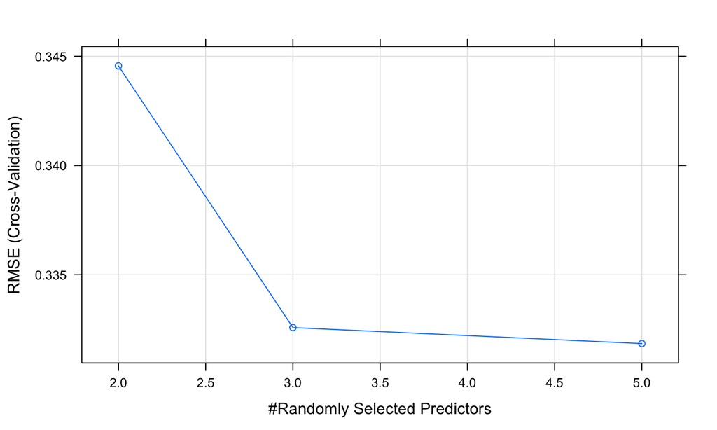

```r
plot(model.iris)
```

- Package is very flexible and will be used for more methods below
- Use tuneGrid function to test specific parameters or models (this example was using default options that may not be useful)

## Regularization

- “penalizing” our model estimates to prevent overfitting
- lasso regression is most common (ridge regression too)
- find coefficients that compromise between (a) minimizing the SS and (b) minimizing sum of abs value of coefficients
- Tends to “shrink”" coefficients to zero
- Shrinkage/penalization is based on lambda

```r
library(glmnet)
library(dplyr)
    fit.ols <- lm(Sepal.Length~Sepal.Width+Petal.Length+Petal.Width, data=iris)
    y <- iris$Sepal.Length
    x <- iris %>% dplyr::select(Sepal.Width, Petal.Length,Petal.Width) %>% data.matrix()
    lambdas <- 10^seq(-4, 1, by = .5)
    fit.lasso <-glmnet(x = x, y = y,  lambda = lambdas)
```

```r
library(broom)

tidy(summary(fit.ols))
```

```
##           term   estimate  std.error statistic      p.value
## 1  (Intercept)  1.8559975 0.25077711  7.400984 9.853855e-12
## 2  Sepal.Width  0.6508372 0.06664739  9.765380 1.199846e-17
## 3 Petal.Length  0.7091320 0.05671929 12.502483 7.656980e-25
## 4  Petal.Width -0.5564827 0.12754795 -4.362929 2.412876e-05
```

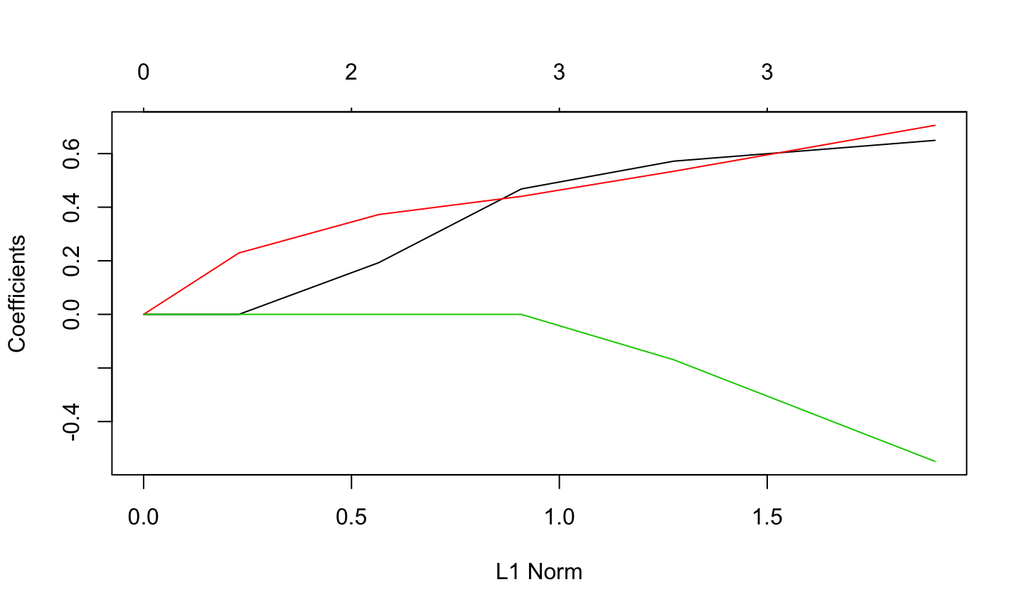

```r
plot(fit.lasso)
```

## Regularization

- Bayesian modeling

## model comparison

- Key to all of these approaches is the utilization of multiple models and comparing them in some mannner
- we have done that thus far with our anova function, which compares model’s MSE using a F-test
- There are other tests that compare models while also taking into account cross-validation and regularization techniques

## Information criteria

- Likelihood: The likelihood of a particular value of a parameter is the probability of obtaining the observed data if the parameter had that value. It measures how well the data supports that particular value
- The maximum likelihood estimate of a parameter is the value of the parameter for which the probability of obtaining the observed data if the highest
- For “nested” models we can compare likelihoods (via log likelihoods) with a chi-square difference test (see this with MLM soon)
- We can also use likelihoods for non-nested models to compare the best “fit” between models

## AIC

- Asymptotically equivalent to cross validation and loo
- AIC = −2 log L + 2p, where L is the maximum likelihood of the data using the model, and p is the number of parameters in the model.
- The first part is a measure of prediction error, the second a penalization
- Lower the AIC the better
- Similar for BIC and WAIC